# Effect Estimation Example

Lucy Mosquera & Mohammad Ehsanul Karim

10/10/2020

# Purpose

The purpose of this electronic supplement is to illustrate the estimators used in the paper. This code and associate provided an example dataset (based on the data from Lipid Research Clinics Coronary Primary Prevention Trial) showing how to calculate intention to treat (ITT), naive per-protocol (naive-PP), baseline adjusted per-protocol (B-PP), and stabilized inverse probability weighted adjusted per-protocol (IPW-PP) effect estimates. These estimators can be used for analyzing pragmatic trials in the presence of non-adherence.

# Data Setup

The analyses conducted in this supplement will require loading the following packages:

```r
# Load required packages
suppressPackageStartupMessages(library(lmtest))
suppressPackageStartupMessages(library(tidyr))
suppressPackageStartupMessages(library(sandwich))
suppressPackageStartupMessages(library(dplyr))
suppressPackageStartupMessages(library(ggstance))
suppressPackageStartupMessages(library(ggplot2))
suppressPackageStartupMessages(library(jtools))
```

Next, by setting the `filePath` variable to match the location of the supplied `Pramgatic Trial Data.csv`, we can open the dataset. By printing the first few rows, we can start getting ourselves familiar with the data.

```r
head(dat)
```

| ID_CPPT | VISIT | maxVisit | TRTMENT | Z | A | Alag1 | outcome | RSTRAT | V5AGE | PHYSA_bl | EDUC | RACE | SYSBPSTD_prev | DSTBPSTD_prev | BMI_prev | NAUS_prev | VOMIT_prev | DIARR_prev | CHOL_prev_yearav | HDL_prev_yearav | LDL_prev_yearav | TG_prev_yearav | CAL_prev | PROT_prev | FAT_prev | CARBT_prev | RQANGINA_prev | GXT_prev | AMSMK_prev | … |
| --- | --- | --- | --- | --- | --- | --- | --- | --- | --- | --- | --- | --- | --- | --- | --- | --- | --- | --- | --- | --- | --- | --- | --- | --- | --- | --- | --- | --- | --- | --- |
| CPPT0002 | 1 | 43 | DRUG | 1 | 0 | 0 | 0 | 7 | 52 | 4 | 2 | NB | 106 | 80 | 2.90 | 0 | 0 | 0 | 256.0 | 29.00000 | 187.6000 | 187.5000 | 2610 | 132 | 99 | 275 | 0 | 0 | 60 | … |
| CPPT0002 | 2 | 43 | DRUG | 1 | 0 | 0 | 0 | 7 | 52 | 4 | 2 | NB | 100 | 74 | 2.85 | 0 | 0 | 0 | 242.5 | 28.16667 | 175.5000 | 185.8000 | 2610 | 132 | 99 | 275 | 0 | 0 | 60 | … |
| CPPT0002 | 3 | 43 | DRUG | 1 | 0 | 0 | 0 | 7 | 52 | 4 | 2 | NB | 100 | 70 | 2.84 | 0 | 0 | 0 | 227.0 | 28.00000 | 161.5000 | 187.5000 | 1430 | 91 | 33 | 142 | 0 | 0 | 60 | … |
| CPPT0002 | 4 | 43 | DRUG | 1 | 0 | 0 | 0 | 7 | 52 | 4 | 2 | NB | 120 | 80 | 2.80 | 0 | 0 | 0 | 208.5 | 30.00000 | 142.6667 | 179.6667 | 1430 | 91 | 33 | 142 | 0 | 0 | 60 | … |
| CPPT0002 | 5 | 43 | DRUG | 1 | 0 | 0 | 0 | 7 | 52 | 4 | 2 | NB | 128 | 90 | 2.78 | 0 | 0 | 0 | 202.0 | 29.83333 | 137.1667 | 175.1667 | 1430 | 91 | 33 | 142 | 0 | 0 | 60 | … |
| CPPT0002 | 6 | 43 | DRUG | 1 | 0 | 0 | 0 | 7 | 52 | 4 | 2 | NB | 126 | 88 | 2.82 | 0 | 0 | 0 | 190.5 | 29.50000 | 126.0000 | 175.8333 | 870 | 49 | 24 | 114 | 0 | 0 | 50 | … |

We see that this dataset consists of 51 variables, including:

- ID_CPPT: patient id that groups observations from the same individual together
- VISIT: Visit number
- maxVisit: maximum visit per patients
- TRTMENT: the arm the patient was randomized to
- Z: binary coded TRTMENT
- A: whether the patient took the treatment for the time interval prior to this observation
- Alag1: lagged value of A
- outcome: whether or not the individual experienced the outcome of interest

Baseline covariates ($B$):

- RSTRAT: Risk stratum
- V5AGE: Age at randomization
- PHYSA_bl: Physical activity level at work at baseline
- EDUC: Educational status
- RACE: Race

Time-varying covariates ($L_t$):

- SYSBPSTD_prev: Systolic blood pressure using Standard device
- DSTBPSTD_prev: Diastolic blood pressure using Standard device
- BMI_prev: Body mass index (grams/ sq.cm)
- NAUS_prev : Nausea
- VOMIT_prev: Vomiting
- DIARR_prev: Diarrhea
- CHOL_prev_yearav: Cholesterol
- HDL_prev_yearav: HDL cholesterol
- LDL_prev_yearav: Estimated LDL cholesterol
- TG_prev_yearav: Triglyceride less blank
- CAL_prev: Calories
- PROT_prev: Protein
- FAT_prev: Total fat
- CARBT_prev: Total carbohydrates
- RQANGINA_prev: R.Q. angina: 1=yes,0=no
- GXT_prev : 1=pos 0=normal GXT
- AMSMK_prev: Cigarettes smoked per day
- ISCT_prev: Ischemia clin cat vis code Ex ecg 42
- ASPCMP_prev: Total # aspirin-cmpd tablets past week
- PHYSB_prev: Physical activity outside of work
- PSRATIO_prev: P/S ratio
- SODIUM_prev: Sodium
- PHOS_prev: Phosphorus
- POT_prev: Potassium
- THYR_prev: Thyroxine
- IRON_prev : Iron
- BILT_prev: Total bilirubin
- BILD_prev: Direct bilirubin
- ALK_prev: Alkaline phosphatase
- CREAT_prev: Creatinine
- GLUC_prev: Fasting glucose
- ALBU_prev: Albumin
- CALC_prev: Calcium
- WBC_prev: White blood cell count
- vascular_prev.indicator: Vascular events
- other.coronary_prev.indicator: Non-fatal/non-MI coronary events
- vascular_prev_hx: Vascular events hx
- other.coronary_prev_hx: Non-fatal/non-MI coronary events hx

# Data Exploration

To better understand the dataset, we can explore the distribution of patients and observations per patient.

```r
n <- length(unique(dat$ID_CPPT))
n1 <- length(unique(dat$ID_CPPT[dat$Z == 1]))
n0 <- length(unique(dat$ID_CPPT[dat$Z == 0]))
averageObs <- mean(table(dat$ID_CPPT))

cat(n, "participants total", "\n",
    n1, "were randomized to the treatment arm", "\n",
    n0, "were randomized to the control arm.", "\n",
    "On average each patient has ", round(averageObs, 1), "observations")
```

```
## 3437 participants total
##  1721 were randomized to the treatment arm
##  1716 were randomized to the control arm.
##  On average each patient has  38.7 observations
```

So there are more than 1700 individuals in each treatment arm with approximately 39 observations per person. The proportion of trial participants who experience the event of interest in the trial dataset is:

```r
# Event rate
e.rate <- sum(dat$outcome)/length(unique(dat$ID_CPPT))
cat("Event rate is", round(e.rate*100,1), "%\n")
```

```
## Event rate is 7.2 %
```

Next, we can quantify non-adherence within the trial by calculating what proportion of individuals became non-adherent by their last observation:

```r
# Non-adherence rates by arm

# How many person-time deviated in the treatment arm?
dat.treated <- dat[dat$Z==1 & dat$Alag1==1,]
pt1dev = dim(dat.treated[dat.treated$A==0,])[1]/n1

# How many person-time deviated in the control arm?
dat.control <- dat[dat$Z==0 & dat$Alag1==0,]
pt0dev = dim(dat.control[dat.control$A==1,])[1]/n0

cat("In the treatment arm,", round(pt1dev*100, 2), "% were nonadherent",
    "\n",
    "In the control arm,", round(pt0dev*100, 2), "% were nonadherent")
```

```
## In the treatment arm, 44.1 % were nonadherent
##  In the control arm, 0 % were nonadherent
```

# Intention to Treat Estimation

The first treatment effect is the Intention To Treat (ITT) effect estimate. This quantifies the causal effect of being randomized to the treatment arm vs. the control arm. In trials with perfect adherence, where all patients receive the treatment they are randomized to receive, this corresponds with the causal effect of receiving treatment.

To estimate the ITT effect, we use pooled logistic regression of the form:

$$logit(Pr(Y=1)) = \gamma_{0} + \gamma_{Z} Z + \gamma_{t}t,$$
which is estimated via the following code:

```r
ITTFit <- glm(outcome ~ Z + VISIT,
              data = dat,
              family = binomial(link = "logit"))
ITTFit
```

```
##
## Call:  glm(formula = outcome ~ Z + VISIT, family = binomial(link = "logit"),
##     data = dat)
##
## Coefficients:
## (Intercept)            Z        VISIT
##   -6.279851    -0.154941     0.003141
##
## Degrees of Freedom: 132948 Total (i.e. Null);  132946 Residual
## Null Deviance:       3600
## Residual Deviance: 3598  AIC: 3604
```

To calculate the appropriate standard error, p-values, and confidence intervals, extra consideration must be used to account for the clustering of observations in the dataset. As we are using pooled logistic regression, each observation corresponds to a single individual at a given follow-up. This means that observations are not all independent, as we’d expect observations from the same individual to be more similar to each other than other observations from another individual. We calculate the appropriate uncertainty for each estimate using clustered sandwich estimates of the standard error:

```r
cov.m1 <- vcovCL(ITTFit, type = "HC0", cluster= dat$ID_CPPT)
co.test <- coeftest(ITTFit, vcov = cov.m1)
co.CI <- coefci(ITTFit, vcov = cov.m1, level = 0.95)
cat("ITT effect estimate:", "\n",
        "log(OR)", round(coefficients(ITTFit)[["Z"]],3), "\n",
      "95% CI:", round(co.CI["Z","2.5 %"],3), ",", round(co.CI["Z","97.5 %"],3), "\n",
      "p-value", round(co.test["Z","Pr(>|z|)"],2), "\n",
      "robust standard error", round(sqrt(diag(cov.m1))[["Z"]],3))
```

```
## ITT effect estimate:
##  log(OR) -0.155
##  95% CI: -0.405 , 0.096
##  p-value 0.23
##  robust standard error 0.128
```

Our ITT estimate concludes that treatment does not have a statistically significant effect on the outcome. We have showed the calculation above in details to explain how exactly clustered sandwich estimates of the standard error are calculated to make proper inference.

Alternatively, we can use `summ()` function from `jtools` package to perform the above calculations for `log(OR)` in a straightforward manner by specifying appropriate arguments.

```r
require(jtools)
summ(ITTFit, robust = "HC0",
     confint = TRUE, digits = 3, cluster="ID_CPPT",
     model.info = FALSE, model.fit = FALSE)
```

|  | Est. | 2.5% | 97.5% | z val. | p |
| --- | --- | --- | --- | --- | --- |
| (Intercept) | -6.280 | -6.552 | -6.007 | -45.191 | 0.000 |
| Z | -0.155 | -0.405 | 0.096 | -1.212 | 0.225 |
| VISIT | 0.003 | -0.007 | 0.013 | 0.601 | 0.548 |

Standard errors: Cluster-robust, type = HC0

We can also do the same for `OR`:

```r
summ(ITTFit, robust = "HC0", exp = TRUE,
     confint = TRUE, digits = 3, cluster="ID_CPPT",
     model.info = FALSE, model.fit = FALSE)
```

|  | exp(Est.) | 2.5% | 97.5% | z val. | p |
| --- | --- | --- | --- | --- | --- |
| (Intercept) | 0.002 | 0.001 | 0.002 | -45.191 | 0.000 |
| Z | 0.856 | 0.667 | 1.100 | -1.212 | 0.225 |
| VISIT | 1.003 | 0.993 | 1.013 | 0.601 | 0.548 |

Standard errors: Cluster-robust, type = HC0

# Naive Per Protocol Estimation

The next effect estimate we calculate is the naive Per Protocol (naive-PP) estimate. This corresponds to comparing all those who were randomized to receive the treatment, and truly did receive it against those who were randomized to receive the control and truly did receive the control.

The estimation of this treatment effect corresponds to:

$$logit(Pr(Y=1)) = \gamma_{0} + \gamma_{A} A + \gamma_{t} t.$$

For this estimate, we start by artificially censoring the dataset so that we only retain observations from individuals at time points where they were adherent to their randomized treatment. Those randomly assigned to the treatment group can take the treatment or placebo, while those randomly assigned to the placebo have only access to the placebo.

```r
## First artificially censor the original data within each arm
dat.treated <- dat[dat$Z==1 & dat$Alag1==1,]
dat.control <- dat[dat$Z==0,]

## Join these to form the complete artificially censored dataset
dat.combined <- rbind(dat.treated, dat.control)
head(dat.combined)
```

| ID_CPPT | VISIT | maxVisit | TRTMENT | Z | A | Alag1 | outcome | RSTRAT | V5AGE | PHYSA_bl | EDUC | RACE | SYSBPSTD_prev | DSTBPSTD_prev | BMI_prev | NAUS_prev | VOMIT_prev | DIARR_prev | CHOL_prev_yearav | HDL_prev_yearav | LDL_prev_yearav | TG_prev_yearav | CAL_prev | PROT_prev | FAT_prev | CARBT_prev | RQANGINA_prev | GXT_prev | AMSMK_prev | … |
| --- | --- | --- | --- | --- | --- | --- | --- | --- | --- | --- | --- | --- | --- | --- | --- | --- | --- | --- | --- | --- | --- | --- | --- | --- | --- | --- | --- | --- | --- | --- |
| CPPT0008 | 1 | 15 | DRUG | 1 | 1 | 1 | 0 | 7 | 55 | 4 | 4 | NB | 118 | 76 | 2.22 | 0 | 0 | 0 | 269.0000 | 54.80000 | 196.8000 | 87.80000 | 2470 | 66 | 98 | 330 | 0 | 0 | 20 | … |
| CPPT0008 | 2 | 15 | DRUG | 1 | 0 | 1 | 0 | 7 | 55 | 4 | 4 | NB | 118 | 82 | 2.18 | 1 | 0 | 0 | 252.8333 | 53.33333 | 182.5000 | 85.33333 | 2470 | 66 | 98 | 330 | 0 | 0 | 20 | … |
| CPPT0009 | 1 | 43 | DRUG | 1 | 1 | 1 | 0 | 7 | 52 | 2 | 4 | NB | 148 | 90 | 3.25 | 0 | 0 | 0 | 295.6000 | 44.20000 | 194.2000 | 340.60000 | 1110 | 70 | 32 | 135 | 0 | 0 | 40 | … |
| CPPT0009 | 2 | 43 | DRUG | 1 | 0 | 1 | 0 | 7 | 52 | 2 | 4 | NB | 150 | 90 | 3.13 | 0 | 0 | 0 | 289.0000 | 44.33333 | 186.5000 | 337.16667 | 1110 | 70 | 32 | 135 | 0 | 0 | 40 | … |
| CPPT0012 | 1 | 43 | DRUG | 1 | 1 | 1 | 0 | 6 | 47 | 3 | 1 | NB | 144 | 86 | 2.53 | 0 | 0 | 0 | 317.8000 | 68.00000 | 209.0000 | 203.80000 | 2170 | 100 | 70 | 178 | 0 | 0 | 20 | … |
| CPPT0012 | 2 | 43 | DRUG | 1 | 1 | 1 | 0 | 6 | 47 | 3 | 1 | NB | 150 | 92 | 2.52 | 0 | 0 | 0 | 323.8333 | 67.50000 | 211.6667 | 223.16667 | 2170 | 100 | 70 | 178 | 0 | 0 | 20 | … |

Next we fit the pooled logistic regression model:

```r
naivePPFit <- glm(outcome ~ A + VISIT,
                  data = dat.combined,
                  family = binomial(link="logit"))
naivePPFit
```

```
##
## Call:  glm(formula = outcome ~ A + VISIT, family = binomial(link = "logit"),
##     data = dat.combined)
##
## Coefficients:
## (Intercept)            A        VISIT
##   -6.308900    -0.474842     0.005005
##
## Degrees of Freedom: 83080 Total (i.e. Null);  83078 Residual
## Null Deviance:       2270
## Residual Deviance: 2265  AIC: 2271
```

Lastly, we calculate the appropriate standard error, p-values, and confidence intervals using the clustered sandwich standard errors:

```r
cov.m1 <- vcovCL(naivePPFit, type = "HC0",
                 cluster = dat.combined$ID_CPPT)
co.test <- coeftest(naivePPFit, vcov = cov.m1)
co.CI <- coefci(naivePPFit, vcov = cov.m1, level = 0.95)
cat("Naive-PP effect estimate:", "\n",
        "log(OR)", round(coefficients(naivePPFit)[["A"]],3), "\n",
      "95% CI:", round(co.CI["A","2.5 %"],3), ",",round(co.CI["A","97.5 %"],3), "\n",
      "p-value", round(co.test["A","Pr(>|z|)"],3), "\n",
      "robust standard error", round(sqrt(diag(cov.m1))[["A"]],3))
```

```
## Naive-PP effect estimate:
##  log(OR) -0.475
##  95% CI: -0.955 , 0.005
##  p-value 0.053
##  robust standard error 0.245
```

The naive-PP estimate concludes that the effect of treatment is insignificant. Alternatively, we can again use the `summ()` function to obtain the same estimates:

```r
summ(naivePPFit, robust = "HC0",
     confint = TRUE, digits = 3, cluster="ID_CPPT",
     model.info = FALSE, model.fit = FALSE)
```

|  | Est. | 2.5% | 97.5% | z val. | p |
| --- | --- | --- | --- | --- | --- |
| (Intercept) | -6.309 | -6.626 | -5.992 | -39.052 | 0.000 |
| A | -0.475 | -0.955 | 0.005 | -1.939 | 0.053 |
| VISIT | 0.005 | -0.008 | 0.018 | 0.783 | 0.434 |

Standard errors: Cluster-robust, type = HC0

# Adjusted Per Protocol Estimation

The last estimates to calculate are the adjusted PP estimates, including the baseline adjusted and stabilized IPW adjusted PP estimates. These estimates aim to adjust for bias introduced by only analyzing the cohort of adherent patients.

## Baseline Adjusted Per Protocol Estimation

Baseline adjusted PP estimates use the subset of patient observations where treatments adhered to their randomly assigned treatments to calculate the effect estimate in the following form:

$$logit(Pr(Y=1)) = \gamma_{0} + \gamma_{A} A + \gamma_{B} B + \gamma_{t} t.$$

Using the artificially censored dataset of adherent patient observations, we fit the pooled logistic regression:

```r
BAdjPPFit <- glm(outcome ~ A + RSTRAT + V5AGE + PHYSA_bl + EDUC + RACE + VISIT,
                 data = dat.combined,
                 family = binomial(link = "logit"))
BAdjPPFit
```

```
##
## Call:  glm(formula = outcome ~ A + RSTRAT + V5AGE + PHYSA_bl + EDUC +
##     RACE + VISIT, family = binomial(link = "logit"), data = dat.combined)
##
## Coefficients:
## (Intercept)            A      RSTRAT2      RSTRAT3      RSTRAT4      RSTRAT5
##   -5.795348    -0.508997    -0.334692    -0.695967    -1.179469    -1.073217
##     RSTRAT6      RSTRAT7      RSTRAT8        V5AGE    PHYSA_bl2    PHYSA_bl3
##   -1.255817    -1.244484    -1.581289    -0.005293     0.423646     0.251958
##   PHYSA_bl4    PHYSA_bl5         EDUC       RACENB        VISIT
##    0.322203    -0.497411    -0.052635     0.907861     0.005578
##
## Degrees of Freedom: 83080 Total (i.e. Null);  83064 Residual
## Null Deviance:       2270
## Residual Deviance: 2242  AIC: 2276
```

Then similar to our previous models we calculate the clustered standard errors:

```r
cov.m1 <- vcovCL(BAdjPPFit, type = "HC0",
                 cluster = dat.combined$ID_CPPT)
co.test <- coeftest(BAdjPPFit, vcov = cov.m1)
co.CI <- coefci(BAdjPPFit, vcov = cov.m1, level = 0.95)

cat("Baseline adjusted PP effect estimate:", "\n",
        "log(OR)", round(coefficients(BAdjPPFit)[["A"]],3), "\n",
      "95% CI:", round(co.CI["A","2.5 %"],3), ",",round(co.CI["A","97.5 %"],3), "\n",
      "p-value", round(co.test["A","Pr(>|z|)"],3), "\n",
      "robust standard error", round(sqrt(diag(cov.m1))[["A"]],3))
```

```
## Baseline adjusted PP effect estimate:
##  log(OR) -0.509
##  95% CI: -0.988 , -0.03
##  p-value 0.037
##  robust standard error 0.244
```

Alternatively, we can again use the `summ()` function to obtain the same estimates:

```r
summ(BAdjPPFit, robust = "HC0",
     confint = TRUE, digits = 3, cluster="ID_CPPT",
     model.info = FALSE, model.fit = FALSE)
```

|  | Est. | 2.5% | 97.5% | z val. | p |
| --- | --- | --- | --- | --- | --- |
| (Intercept) | -5.795 | -8.320 | -3.271 | -4.499 | 0.000 |
| A | -0.509 | -0.988 | -0.030 | -2.082 | 0.037 |
| RSTRAT2 | -0.335 | -1.520 | 0.851 | -0.553 | 0.580 |
| RSTRAT3 | -0.696 | -2.377 | 0.986 | -0.811 | 0.417 |
| RSTRAT4 | -1.179 | -2.648 | 0.289 | -1.574 | 0.115 |
| RSTRAT5 | -1.073 | -2.056 | -0.090 | -2.140 | 0.032 |
| RSTRAT6 | -1.256 | -2.233 | -0.279 | -2.519 | 0.012 |
| RSTRAT7 | -1.244 | -2.238 | -0.251 | -2.454 | 0.014 |
| RSTRAT8 | -1.581 | -2.576 | -0.587 | -3.116 | 0.002 |
| V5AGE | -0.005 | -0.035 | 0.025 | -0.348 | 0.728 |
| PHYSA_bl2 | 0.424 | -0.240 | 1.087 | 1.251 | 0.211 |
| PHYSA_bl3 | 0.252 | -0.406 | 0.909 | 0.751 | 0.453 |
| PHYSA_bl4 | 0.322 | -0.367 | 1.012 | 0.916 | 0.360 |
| PHYSA_bl5 | -0.497 | -1.586 | 0.591 | -0.895 | 0.371 |
| EDUC | -0.053 | -0.187 | 0.082 | -0.767 | 0.443 |
| RACENB | 0.908 | -0.495 | 2.311 | 1.268 | 0.205 |
| VISIT | 0.006 | -0.007 | 0.018 | 0.876 | 0.381 |

Standard errors: Cluster-robust, type = HC0

The baseline adjusted-PP estimate concludes that the effect of treatment is significant, with a log odds ratio of -0.5089966. This result would indicate that the receipt of treatment is associated with a lower risk of experiencing the outcome. However, baseline adjusted-PP estimates may be subject to bias if non-adherence depends on post-baseline prognostic factors.

## Inverse Probability Weighted Per Protocol Estimation

### Deriving Inverse Probability Weights

To fit the IPW-adjusted PP estimates, first, the weights are calculated for each observation. The stabilized weights for individual $i$’s $t$th observation is given by:

$$W_{i,t} = \prod_{t=1}^{t} \frac{P(A_{t} |B, t)}{P(A_{t} |B, t, L_{t})},$$
where $P(A_{t} |B, t)$ are the predicted values from logistic regression of the form:

$$logit(Pr(A_{t}=1)) = \gamma_{t} t + \gamma_{B} B,$$

and $P(A_{t} |B, t, L_{1,t}, L_{2, t})$ are the predicted values from logistic regression of the form:

$$logit(Pr(A_{t}=1)) = \gamma_{t} t + \gamma_{B} B + \gamma_{L} L_{t}.$$

To calculate these weights, we censor the complete dataset to include adherent observations:

```r
## First artificially censor the original data within each arm
dat.treated <- dat[dat$Z==1 & dat$Alag1==1,]
dat.control <- dat[dat$Z==0,]
```

We then fit the regression models for the numerator and the denominators, separately for each arm, starting with arm $Z=1$:

```r
#Create IP of artificial censoring weights
#For records with Z=1

# Calculate numerator alpha_hat coeffs for stabilized IP weights
numprob.tr <- glm(A ~ RSTRAT + V5AGE + PHYSA_bl + EDUC + RACE + VISIT,
                 data = dat.treated,
                 family = binomial(link = "logit"))

# Calculate denominator alpha_hat coeffs for stabilized IP weights
denomprob.tr <- glm(A ~ RSTRAT + V5AGE + PHYSA_bl + EDUC + RACE + VISIT +
                      SYSBPSTD_prev + DSTBPSTD_prev + BMI_prev + NAUS_prev + VOMIT_prev +
                      DIARR_prev + CHOL_prev_yearav + HDL_prev_yearav + LDL_prev_yearav +
                      TG_prev_yearav + CAL_prev + PROT_prev + FAT_prev + CARBT_prev +
                      RQANGINA_prev + GXT_prev + AMSMK_prev + ISCT_prev + ASPCMP_prev +
                      PHYSB_prev + PSRATIO_prev + SODIUM_prev + PHOS_prev + POT_prev +
                      THYR_prev + IRON_prev + BILT_prev + BILD_prev + ALK_prev +
                      CREAT_prev + GLUC_prev + ALBU_prev + CALC_prev + WBC_prev +
                      vascular_prev.indicator + other.coronary_prev.indicator +
                      vascular_prev_hx + other.coronary_prev_hx,
                   data = dat.treated,
                   family = binomial(link = "logit"))
```

Using the predicted probabilities, we can calculate the stabilized IPW, as well as the truncated stabilized IPW:

```r
# Calculating weights from the predicted probabilities
dat.treated <- dat.treated %>%
    # Derive the weight contributions at each time point
    mutate(wgt_temp = ifelse(A == 1,
                             predict(numprob.tr, dat.treated, type = "response") /
                               predict(denomprob.tr, dat.treated, type = "response"),
                             0)) %>%
    # Group data by patient
    group_by(ID_CPPT) %>%

    # Cumulative multiply the weight contributions within each patient
    mutate(sipw = cumprod(wgt_temp)) %>%
    ungroup() %>%

    # Create truncated IPW weights
    mutate(tsipw = pmin(pmax(sipw, quantile(sipw, .05)),
                                            quantile(sipw, .95)))%>%
    ungroup()
```

Then we repeat the process for arm $Z=0$ by fitting the regression models. For our case, the weight will be 1 since the nonadherence rate is 0% in the control group.

```r
#For records with Z=0
dat.control$wgt_temp <- dat.control$sipw <- dat.control$tsipw <- 1
```

Now we can assess the weights by checking the mean and standard deviation of the stabilized vs. the truncated stabilized weights:

```r
# Assess the weights generated

# Join arm 1 and arm 2 datasets
dat.combined <- rbind(dat.control, dat.treated)

dat.combined %>%
    ungroup() %>%
    summarize(mean_SIPW = mean(sipw),
                        sd_SIPW = sd(sipw),
                        mean_TSIPW = mean(tsipw),
                        sd_TWIPW = sd(tsipw))
```

| mean_SIPW | sd_SIPW | mean_TSIPW | sd_TWIPW |
| --- | --- | --- | --- |
| 1.038986 | 0.1572664 | 1.047811 | 0.121085 |

We see the weights are reasonably close to 1, and that truncation reduces the standard deviation of the weights.

### Fitting Weighted Outcome Models

To get the effect estimates, we perform weighted pooled logistic regression according to the following model:

$$logit(Pr(Y=1) = \gamma_{0} + \gamma_{A} A + \gamma_{B} B + \gamma_{t} t.$$

```r
SIPWFit <- glm(outcome ~ A + RSTRAT + V5AGE + PHYSA_bl + EDUC + RACE + VISIT,
               data = dat.combined,
               family = binomial(link = "logit"),
                             weight = sipw)
SIPWFit
```

```
##
## Call:  glm(formula = outcome ~ A + RSTRAT + V5AGE + PHYSA_bl + EDUC +
##     RACE + VISIT, family = binomial(link = "logit"), data = dat.combined,
##     weights = sipw)
##
## Coefficients:
## (Intercept)            A      RSTRAT2      RSTRAT3      RSTRAT4      RSTRAT5
##   -6.364314    -0.527005    -0.407188    -0.733275    -1.466853    -1.133994
##     RSTRAT6      RSTRAT7      RSTRAT8        V5AGE    PHYSA_bl2    PHYSA_bl3
##   -1.327567    -1.276714    -1.637942    -0.006526     0.435351     0.250276
##   PHYSA_bl4    PHYSA_bl5         EDUC       RACENB        VISIT
##    0.286351    -0.520486    -0.062028     1.609888     0.006373
##
## Degrees of Freedom: 82321 Total (i.e. Null);  82305 Residual
## Null Deviance:       2300
## Residual Deviance: 2266  AIC: 2250
```

```r
cov.m1 <- vcovCL(SIPWFit, type = "HC0", cluster = dat.combined$ID_CPPT)
co.test <- coeftest(SIPWFit, vcov = cov.m1)
co.CI <- coefci(SIPWFit, vcov = cov.m1, level = 0.95)

cat("Stabilized IPW adjusted PP effect estimate:", "\n",
        "log(OR)", round(coefficients(SIPWFit)[["A"]],3), "\n",
      "95% CI:", round(co.CI["A","2.5 %"],3), ",",round(co.CI["A","97.5 %"],3), "\n",
      "p-value", round(co.test["A","Pr(>|z|)"],3), "\n",
      "robust standard error", round(sqrt(diag(cov.m1))[["A"]],3))
```

```
## Stabilized IPW adjusted PP effect estimate:
##  log(OR) -0.527
##  95% CI: -1.007 , -0.047
##  p-value 0.031
##  robust standard error 0.245
```

Alternatively, we can again use the `summ()` function to obtain the same estimates:

```r
summ(SIPWFit, robust = "HC0",
     confint = TRUE, digits = 3, cluster="ID_CPPT",
     model.info = FALSE, model.fit = FALSE)
```

|  | Est. | 2.5% | 97.5% | z val. | p |
| --- | --- | --- | --- | --- | --- |
| (Intercept) | -6.364 | -9.158 | -3.571 | -4.465 | 0.000 |
| A | -0.527 | -1.007 | -0.047 | -2.153 | 0.031 |
| RSTRAT2 | -0.407 | -1.589 | 0.774 | -0.675 | 0.499 |
| RSTRAT3 | -0.733 | -2.403 | 0.936 | -0.861 | 0.389 |
| RSTRAT4 | -1.467 | -3.124 | 0.191 | -1.734 | 0.083 |
| RSTRAT5 | -1.134 | -2.117 | -0.151 | -2.260 | 0.024 |
| RSTRAT6 | -1.328 | -2.302 | -0.353 | -2.671 | 0.008 |
| RSTRAT7 | -1.277 | -2.267 | -0.287 | -2.528 | 0.011 |
| RSTRAT8 | -1.638 | -2.628 | -0.648 | -3.244 | 0.001 |
| V5AGE | -0.007 | -0.037 | 0.024 | -0.423 | 0.672 |
| PHYSA_bl2 | 0.435 | -0.225 | 1.096 | 1.292 | 0.196 |
| PHYSA_bl3 | 0.250 | -0.403 | 0.904 | 0.751 | 0.453 |
| PHYSA_bl4 | 0.286 | -0.400 | 0.973 | 0.818 | 0.414 |
| PHYSA_bl5 | -0.520 | -1.601 | 0.560 | -0.944 | 0.345 |
| EDUC | -0.062 | -0.197 | 0.073 | -0.901 | 0.368 |
| RACENB | 1.610 | -0.327 | 3.547 | 1.629 | 0.103 |
| VISIT | 0.006 | -0.006 | 0.019 | 0.990 | 0.322 |

Standard errors: Cluster-robust, type = HC0

The IPW adjusted-PP estimate concludes that the effect of treatment is significant, with a log odds ratio of -0.5270045. This result suggests that those who received the treatment were associated with a lower risk of experiencing the outcome. Note that, this model can alternatively use the truncated stabilized weights by switching the weight used in the regression calculation from `sipw` to `tsipw`.

# Compare Results

Comparing `log(OR)` from all models (vertical line represents the true parameter for `log(OR)` when we generated the simulated data):

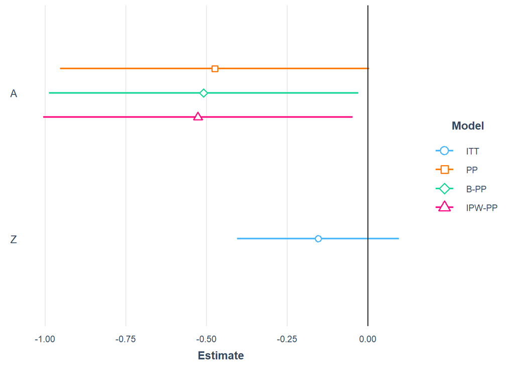

```r
plot_summs(ITTFit, naivePPFit, BAdjPPFit, SIPWFit,
           scale = TRUE,
           coefs = c("A", "Z"),
           robust = list("HC0","HC0","HC0", "HC0"),
           model.names = c("ITT", "PP", "B-PP", "IPW-PP")) +
geom_vline(xintercept = 0)
```

Comparing `OR` from all models (vertical line represents the true parameter for `OR` when we generated the simulated data):

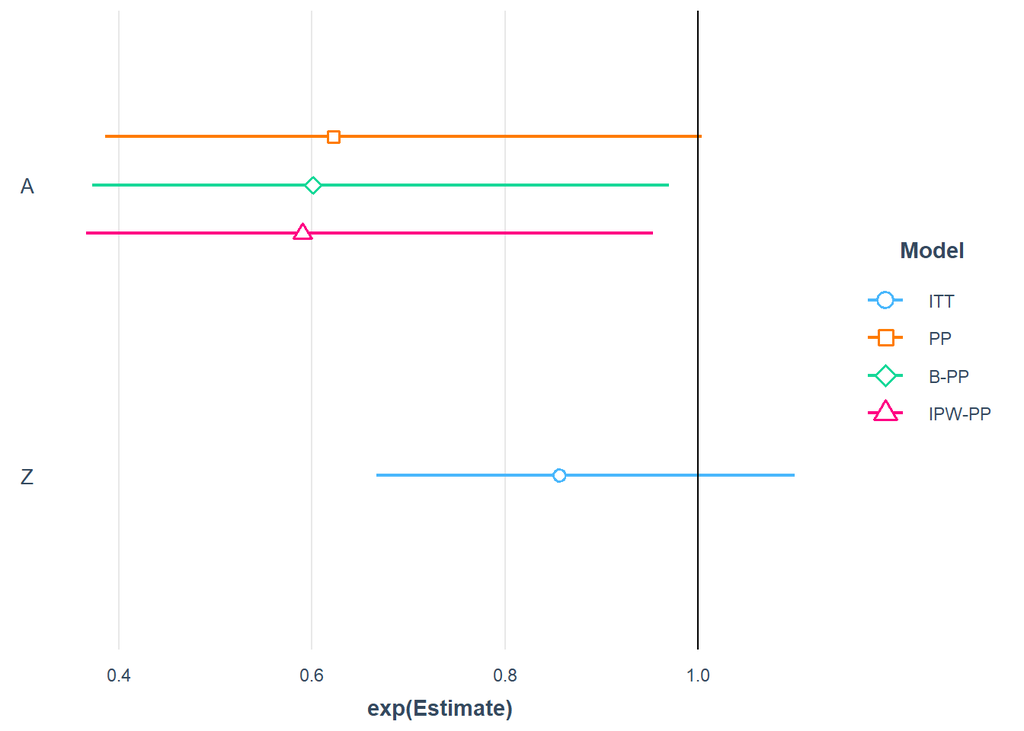

```r
plot_summs(ITTFit, naivePPFit, BAdjPPFit, SIPWFit,
           scale = TRUE,
           coefs = c("A", "Z"),
           exp = TRUE,
           robust = list("HC0","HC0","HC0", "HC0"),
           model.names = c("ITT", "PP", "B-PP", "IPW-PP")) +
geom_vline(xintercept = 1)
```

# Further Reference about Computation

Readers can take a look at the additional files from Young JG et al. Trials 2019; 20(1). doi: 10.1186/s13063-019-3577-z for further details about computing cumulative survival type estimates of the ITT, naive-PP, and IPW adjusted-PP average causal effect of treatment.